# Ejercicio práctico Clustering

Bryan Casanova - José Godoy

20-07-2022

# 1. Planteamiento del problema

Para este ejercicio nos enfocaremos en los negocios que peor lo están pasando con esta crisis, los pequeños negocios. Las pequeñas empresas representan el 99% de todas las empresas en Estados Unidos y casi el 50% del empleo, así que son un motor indispensable para el desarrollo económico.

Todos los años, la Administración de Pequeñas Empresas de EE.UU. (SBA) publica una informe anual de la actividad de las pequeñas empresas en cada estado. Para este ejercicio, utilizaremos parte de los datos publicados por este organismo público e intentaremos obtener alguna conclusión mediante el Clustering.

El dataset y el diccionario de datos podrás encontrarlo en la carpeta data.

Así pues, lo primero que haremos es cargar el dataset en R:

```r
# Carga paquetes necesarios
require(factoextra)

# Carga el dataset
datos <- read.csv("4.4_Cluster_ejercicio.csv")
head(datos)
```

```
##        State PercentSmallBiz PercentEmplySmallBiz AvgEmPerSmallBiz
## 1    Alabama       0.9936905            0.4746900              2.0
## 2     Alaska       0.9912795            0.5315244              2.0
## 3    Arizona       0.9942976            0.4449635              1.8
## 4   Arkansas       0.9927139            0.4782382              1.9
## 5 California       0.9984648            0.4883776              1.8
## 6   Colorado       0.9946615            0.4861072              1.8
##   MedIncomeSelfEmpCorp MedIncomeSelfEmpUnincorp PercentExportSmallBiz
## 1                48941                    20760                 0.804
## 2                60559                    30817                 0.710
## 3                48698                    20872                 0.874
## 4                45044                    21128                 0.781
## 5                57420                    25034                 0.957
## 6                49977                    24631                 0.875
##   PercentExportValue StateGDPGrowth StateUnemployRate ShareManufactEmploy
## 1              0.155           0.03              0.04                0.34
## 2              0.384           0.02              0.07                0.35
## 3              0.231           0.03              0.05                0.46
## 4              0.283           0.02              0.04                0.26
## 5              0.432           0.03              0.04                0.53
## 6              0.306           0.04              0.03                0.52
##   AvgEmpPerWOB AvgEmpPerVOB AvgEmpPerMOB ShareProSvcEmploy GrowthNumPropiertors
## 1         11.8         10.7          9.5              0.62                 0.02
## 2          5.6          6.5          6.4              0.59                 0.01
## 3          8.3         11.5          9.4              0.56                 0.03
## 4          8.2          7.8          7.7              0.71                 0.02
## 5          7.9         10.1          8.5              0.55                 0.03
## 6          6.1          8.6          7.6              0.57                 0.02
```

## 1.1 Preparación del dataset.

Tal y como podrás comprobar, el dataset tiene una dimensión de 51 observaciones (correspondientes a cada uno de los estados federales de USA) y 16 variables (correspondientes a datos económicos relativos a pequeños negocios). Si necesitas más información acerca de qué significa cada variable, podrás encontrarla en el diccionario de datos.

Tal y como podrás comprobar, existen ciertas variables en las cuales hay asteriscos. Estos representan valores nulos (NA). Por tanto, hay que hacer un tratamiento de estas variables para poder aplicar el clustering.

- **Ejercicio 1**: Reemplaza los valores nulos (asteriscos) por la mediana y transforma las variables tratadas a tipo numerico.

```r
# Reemplazo los valores nulos por la mediana
# Modifico el tipo de las variables tratadas a numerico
for (i in 2:ncol(datos)){
  datos[,i] <- as.numeric(datos[,i])
  datos[,i][is.na(datos[,i])] <- median(datos[,i], na.rm = T)
}
summary(datos)
```

```
##     State           PercentSmallBiz  PercentEmplySmallBiz AvgEmPerSmallBiz
##  Length:51          Min.   :0.9817   Min.   :0.4200       Min.   :1.300
##  Class :character   1st Qu.:0.9914   1st Qu.:0.4622       1st Qu.:1.900
##  Mode  :character   Median :0.9937   Median :0.4861       Median :2.100
##                     Mean   :0.9931   Mean   :0.4961       Mean   :2.118
##                     3rd Qu.:0.9951   3rd Qu.:0.5190       3rd Qu.:2.300
##                     Max.   :0.9985   Max.   :0.6524       Max.   :3.300
##  MedIncomeSelfEmpCorp MedIncomeSelfEmpUnincorp PercentExportSmallBiz
##  Min.   :39474        Min.   :18772            Min.   :0.7100
##  1st Qu.:45238        1st Qu.:21367            1st Qu.:0.8260
##  Median :48941        Median :22573            Median :0.8500
##  Mean   :49162        Mean   :24030            Mean   :0.8483
##  3rd Qu.:51421        3rd Qu.:25530            3rd Qu.:0.8820
##  Max.   :66500        Max.   :36377            Max.   :0.9570
##  PercentExportValue StateGDPGrowth    StateUnemployRate ShareManufactEmploy
##  Min.   :0.1030     Min.   :0.01000   Min.   :0.02000   Min.   :0.2600
##  1st Qu.:0.2425     1st Qu.:0.02000   1st Qu.:0.03000   1st Qu.:0.3600
##  Median :0.2890     Median :0.03000   Median :0.04000   Median :0.4600
##  Mean   :0.3360     Mean   :0.02961   Mean   :0.04157   Mean   :0.4592
##  3rd Qu.:0.3835     3rd Qu.:0.04000   3rd Qu.:0.05000   3rd Qu.:0.5200
##  Max.   :0.7950     Max.   :0.06000   Max.   :0.07000   Max.   :0.7900
##   AvgEmpPerWOB     AvgEmpPerVOB    AvgEmpPerMOB    ShareProSvcEmploy
##  Min.   : 5.600   Min.   : 6.40   Min.   : 4.700   Min.   :0.2700
##  1st Qu.: 7.500   1st Qu.: 8.25   1st Qu.: 7.000   1st Qu.:0.5500
##  Median : 8.300   Median :10.00   Median : 8.400   Median :0.6150
##  Mean   : 8.141   Mean   :10.26   Mean   : 8.457   Mean   :0.6203
##  3rd Qu.: 8.700   3rd Qu.:11.30   3rd Qu.: 9.550   3rd Qu.:0.6750
##  Max.   :11.800   Max.   :23.70   Max.   :12.300   Max.   :0.9000
##  GrowthNumPropiertors
##  Min.   :0.01000
##  1st Qu.:0.02000
##  Median :0.02000
##  Mean   :0.02176
##  3rd Qu.:0.02000
##  Max.   :0.03000
```

Observamos que existían 4 columnas que contaban con registros faltantes, los cuales ya fueron reemplazados por la mediana de cada columna.

Una vez realizada la imputación de los valores nulos, es necesario que observes el rango de las variables que vas a utilizar para el clustering y valores si es necesario transformarlas o no.

- **Ejercicio 2**: Crea un nuevo dataframe con todas las variables estandarizadas en el cuál cada fila tenga como nombre cada uno de los estados.

```r
# Reescalo las variables creando un nuevo dataframe
datos_scaled <- scale(datos[,-1])
# Añado la variable States como nombre de fila en el nuevo dataframe
rownames(datos_scaled) <- datos$State
# Sumarizo las variables
summary(datos_scaled)
```

```
##  PercentSmallBiz   PercentEmplySmallBiz AvgEmPerSmallBiz   MedIncomeSelfEmpCorp
##  Min.   :-3.3817   Min.   :-1.4818      Min.   :-2.45769   Min.   :-1.67544
##  1st Qu.:-0.4950   1st Qu.:-0.6590      1st Qu.:-0.65421   1st Qu.:-0.67866
##  Median : 0.1872   Median :-0.1937      Median :-0.05304   Median :-0.03815
##  Mean   : 0.0000   Mean   : 0.0000      Mean   : 0.00000   Mean   : 0.00000
##  3rd Qu.: 0.6152   3rd Qu.: 0.4474      3rd Qu.: 0.54812   3rd Qu.: 0.39076
##  Max.   : 1.6142   Max.   : 3.0440      Max.   : 3.55392   Max.   : 2.99864
##  MedIncomeSelfEmpUnincorp PercentExportSmallBiz PercentExportValue
##  Min.   :-1.3557          Min.   :-2.59676      Min.   :-1.5062
##  1st Qu.:-0.6866          1st Qu.:-0.41868      1st Qu.:-0.6043
##  Median :-0.3756          Median : 0.03196      Median :-0.3036
##  Mean   : 0.0000          Mean   : 0.00000      Mean   : 0.0000
##  3rd Qu.: 0.3869          3rd Qu.: 0.63281      3rd Qu.: 0.3073
##  Max.   : 3.1839          Max.   : 2.04105      Max.   : 2.9678
##  StateGDPGrowth     StateUnemployRate ShareManufactEmploy  AvgEmpPerWOB
##  Min.   :-1.96232   Min.   :-2.1410   Min.   :-1.692200   Min.   :-1.8917
##  1st Qu.:-0.96154   1st Qu.:-1.1483   1st Qu.:-0.842769   1st Qu.:-0.4773
##  Median : 0.03925   Median :-0.1557   Median : 0.006662   Median : 0.1182
##  Mean   : 0.00000   Mean   : 0.0000   Mean   : 0.000000   Mean   : 0.0000
##  3rd Qu.: 1.04003   3rd Qu.: 0.8369   3rd Qu.: 0.516321   3rd Qu.: 0.4160
##  Max.   : 3.04160   Max.   : 2.8222   Max.   : 2.809785   Max.   : 2.7237
##   AvgEmpPerVOB       AvgEmpPerMOB      ShareProSvcEmploy  GrowthNumPropiertors
##  Min.   :-1.39697   Min.   :-2.01711   Min.   :-3.40937   Min.   :-2.4626
##  1st Qu.:-0.72689   1st Qu.:-0.78221   1st Qu.:-0.68417   1st Qu.:-0.3694
##  Median :-0.09304   Median :-0.03053   Median :-0.05153   Median :-0.3694
##  Mean   : 0.00000   Mean   : 0.00000   Mean   : 0.00000   Mean   : 0.0000
##  3rd Qu.: 0.37783   3rd Qu.: 0.58692   3rd Qu.: 0.53245   3rd Qu.:-0.3694
##  Max.   : 4.86914   Max.   : 2.06343   Max.   : 2.72235   Max.   : 1.7238
```

## 1.2 Creación de los clusters

Una vez disponemos del dataframe preparado, es necesario estimar el número de clusters óptimo. Pese a que puede ser un proceso subjetivo, existen algunos métodos que pueden ayudarnos a tomar la decisión.

- **Ejercicio 3**: Elige el número de clusters óptimos mediante el método elbow. ¿Observas algún otro número que también podría ser óptimo? Justifica tu respuesta.

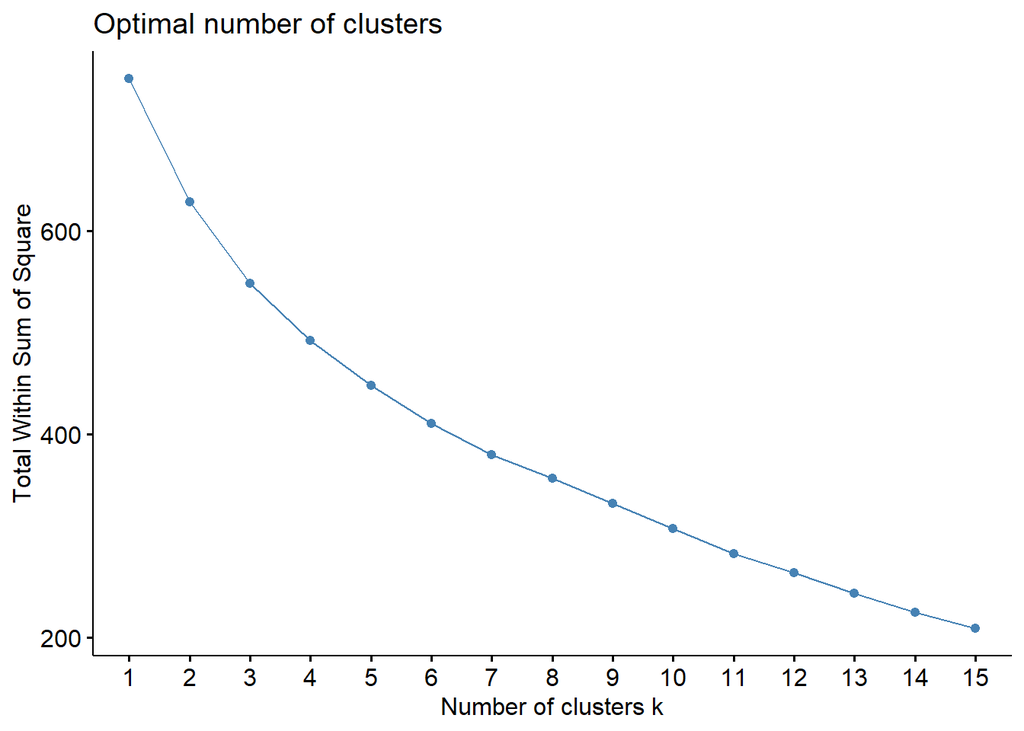

```r
# Visualización del elbow method
fviz_nbclust(x = datos_scaled, FUNcluster = kmeans, method = "wss", k.max = 15,
             diss = get_dist(datos_scaled, method = "euclidean"), nstart = 50)
```

Al visualizar la curva vemos que aún cuando no se observa un “codo” muy marcado o una reducción de la suma total de varianza intra-cluster sustancial, hay una reducción de la varianza entre los 4 a 6 clusters, por lo que contrastaríamos este resultado con el dendrograma antes de decidir el número de clusters a utilizar.

- **Ejercicio 4**: Elige el número de clusters óptimos mediante la representación del dendrograma. ¿Observas algún otro número que también podría ser óptimo? Justifica tu respuesta.

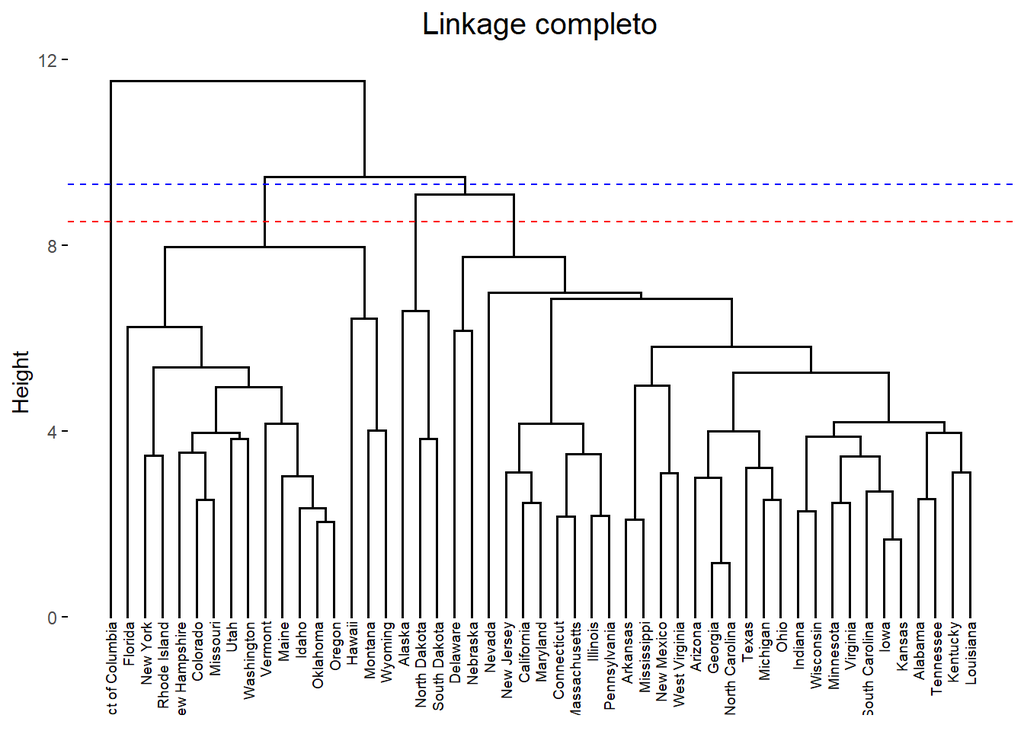

```r
library(factoextra)
# Visualización del dendrograma
set.seed(123)
hc_euclidea_completo <- hclust(d = dist(x = datos_scaled, method = "euclidean"),
                               method = "complete")
fviz_dend(x = hc_euclidea_completo, cex = 0.5, main = "Linkage completo",
          sub = "Distancia euclídea") +
  theme(plot.title =  element_text(hjust = 0.5, size = 15)) +
  geom_hline(yintercept = 8.5, col = "red", linetype = "dashed") +
  geom_hline(yintercept = 9.3, col = "blue", linetype = "dashed")
```

Visualizando el dendrogramo observamos que se podrían escoger 3 clusters, siguiendo la linea horizontal azul, sin embargo, dado que el estado de Columbia presenta un comportamiento bastante inusual ya que es una rama independiente al resto de los estados, se prefiere utilizar 4 clusters, siguiendo la línea horizontal roja, para representar mejor la variabilidad del resto de los estados.

Una vez tomada la decisión del número de clusters a realizar, procedemos a crear y visualizar los clusters en dos dimensiones.

- **Ejercicio 5**: Crea el número de clusters elegido y representalo en dos dimensiones utilizando la función fviz_cluster.

```
## Too few points to calculate an ellipse
```

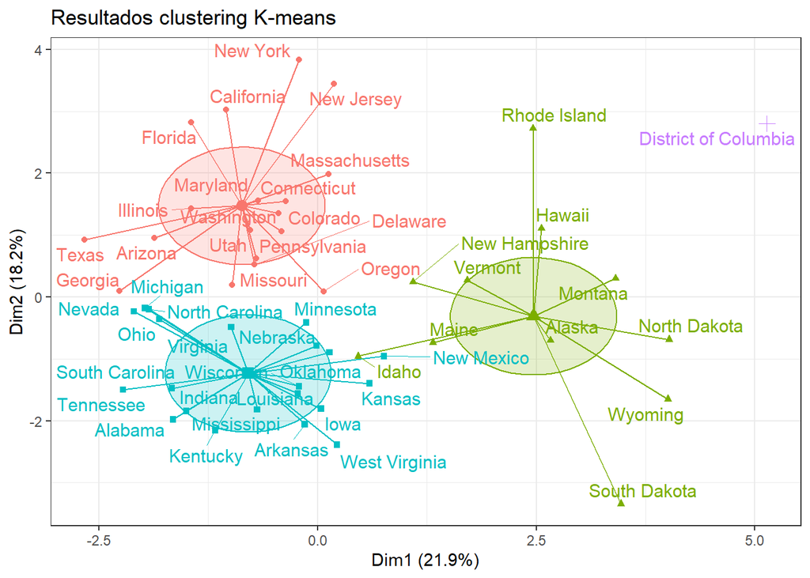

```r
# Creacion de los clusters
set.seed(123)
km_clusters <- kmeans(x = datos_scaled, centers = 4, nstart = 50)

# Visualización de los clusters en 2 dimensiones
fviz_cluster(object = km_clusters, data = datos_scaled, show.clust.cent = TRUE,
             ellipse.type = "euclid", star.plot = TRUE, repel = TRUE) +
  labs(title = "Resultados clustering K-means") +
  theme_bw() +
  theme(legend.position = "none")
```

## 1.3 Interpretación de los clusters

Una vez disponemos de la visualización en dos dimensiones de los estados que pertenecen a cada cluster creado, vamos a la parte interesante, la interpretación de estos.

- **Ejercicio 6**: Elige qué estado consideras que es más representativo de cada cluster. Justifica tu respuesta.

```r
datos_scaled <- as.data.frame(datos_scaled)
datos_scaled$cluster <- km_clusters$cluster

distance_to_center <- function(datos_scaled, k, km_clusters){

  data_filter = datos_scaled[datos_scaled$cluster == k, ]
  center <- km_clusters$centers[k,]
  distance <- Inf
  state <- NULL
  for (row in 1:nrow(data_filter)){
        k_distance <- sqrt(sum(data_filter[row, -1] - center)^2)
    if (k_distance < distance) {
      distance <- k_distance
      state <- row.names(data_filter)[row]
    }

  }
  return (c(state, distance))

}


representantes <- c(distance_to_center(datos_scaled, 1, km_clusters)[1], distance_to_center(datos_scaled, 2, km_clusters)[1], distance_to_center(datos_scaled, 3, km_clusters)[1], distance_to_center(datos_scaled, 4, km_clusters)[1])

print(representantes)
```

```
## [1] "Arizona"              "South Dakota"         "Iowa"
## [4] "District of Columbia"
```

Nota: El cluster 4 solo cuenta con un uno estado!.

- **Ejercicio 7**: Indexa cada uno de los estados más representativos de cada cluster sobre el dataframe inicial y crea un nuevo tablón de datos en el que únicamente se encuentren estos estados. ¿Qué variables difieren en más en valor entre unos estados y otros?

```r
# Selecciono los estados que quiero ver en un vector

# Creo nuevo dataframe sobre el tablon inicial solo con los estados que quiero ver

# Introduce aquí tu respuesta
print( t(datos[datos$State %in% representantes, ]))
```

```
##                          3           9                      16
## State                    "Arizona"   "District of Columbia" "Iowa"
## PercentSmallBiz          "0.9942976" "0.9817498"            "0.9928945"
## PercentEmplySmallBiz     "0.4449635" "0.4739182"            "0.4830516"
## AvgEmPerSmallBiz         "1.8"       "3.3"                  "2.4"
## MedIncomeSelfEmpCorp     "48698"     "66500"                "44504"
## MedIncomeSelfEmpUnincorp "20872"     "34113"                "25494"
## PercentExportSmallBiz    "0.874"     "0.768"                "0.830"
## PercentExportValue       "0.231"     "0.795"                "0.189"
## StateGDPGrowth           "0.03"      "0.02"                 "0.02"
## StateUnemployRate        "0.05"      "0.06"                 "0.03"
## ShareManufactEmploy      "0.46"      "0.77"                 "0.32"
## AvgEmpPerWOB             "8.3"       "9.3"                  "8.5"
## AvgEmpPerVOB             "11.5"      "10.0"                 " 9.1"
## AvgEmpPerMOB             "9.4"       "9.0"                  "8.5"
## ShareProSvcEmploy        "0.56"      "0.46"                 "0.65"
## GrowthNumPropiertors     "0.03"      "0.03"                 "0.02"
##                          42
## State                    "South Dakota"
## PercentSmallBiz          "0.9899325"
## PercentEmplySmallBiz     "0.5931267"
## AvgEmPerSmallBiz         "2.5"
## MedIncomeSelfEmpCorp     "45704"
## MedIncomeSelfEmpUnincorp "31506"
## PercentExportSmallBiz    "0.752"
## PercentExportValue       "0.362"
## StateGDPGrowth           "0.01"
## StateUnemployRate        "0.03"
## ShareManufactEmploy      "0.43"
## AvgEmpPerWOB             "8.3"
## AvgEmpPerVOB             "10.0"
## AvgEmpPerMOB             "8.8"
## ShareProSvcEmploy        "0.81"
## GrowthNumPropiertors     "0.01"
```

- **Ejercicio 8**: ¿Cuál de los estados seleccionados en el ejercicio anterior tiene una tasa de desempleo más elevada?

En primer lugar vamos a asignar la etiqueta de los clusters a los datos originales.

```r
datos$cluster <- km_clusters$cluster

t(aggregate(datos, by = list(datos$cluster), FUN = mean))['StateUnemployRate', ]
```

```
## [1] 0.04388889 0.03636364 0.04142857 0.06000000
```

El cluster que tiene una mayor tasa de desempleo es el cluster 4 con un unico valor

- **Ejercicio 9**: Si el presidente de los Estados Unidos quisiera lanzar una campaña para aumentar el volumen de exportaciones de pequeños negocios hacia el exterior sobre los estados que menos exportan del país, y con menor valor, qué cluster o clusters le propondrías? (Menciona únicamente el estado que consideres más representativo del cluster)

```r
# Introduce aquí tu respuesta

t(aggregate(datos, by = list(datos$cluster), FUN = mean))[c("PercentExportSmallBiz", "PercentExportValue"), ]
```

```
##                            [,1]      [,2]      [,3]  [,4]
## PercentExportSmallBiz 0.8942222 0.8122818 0.8316238 0.768
## PercentExportValue    0.3395000 0.4728273 0.2393857 0.795
```

- **Ejercicio 10**: ¿Qué cluster representa mejor a los pequeños negocios con más ingresos?

```r
# Introduce aquí tu respuesta
t(aggregate(datos, by = list(datos$cluster), FUN = mean))[c("MedIncomeSelfEmpUnincorp"), ]
```

```
## [1] 24250.33 26087.82 22282.14 34113.00
```

Este ejercicio se puntuará con 10 puntos, siendo el mínimo necesario para superar la prueba de 5 puntos. La puntuación es la siguiente:

- Ejercicio 1: 0.5 puntos
- Ejercicio 2: 0.5 puntos
- Ejercicio 3: 1 punto
- Ejercicio 4: 1 punto
- Ejercicio 5: 1.5 puntos
- Ejercicio 6: 1 punto
- Ejercicio 7: 1.5 puntos
- Ejercicio 8: 1 punto
- Ejercicio 9: 1 punto
- Ejercicio 10: 1 punto